# Data Exploration and Cleaning

```python
import pandas as pd
import seaborn as sns
import sqlite3
from pandas_profiling import ProfileReport

path = 'C:/Users/lingj/Documents/Personal/Career/Interview/Apple/App Store Data Scientist/'

%matplotlib inline
```

## Load Dataset Into a Sqlite3 Database

Some data manipulations such as join are much easier to execute in SQL, I therefore first create the database for this project.

### Create a New Database

```
sqlite
.open --new main.db
```

### Create Tables

```
sqlite
create table account_dat(acct_id text, create_dt text, payment_type text);
create table app_dat(app_name text, content_id text, category_id text, device_id integer);
create table in_app_dat(parent_app_content_id text, content_id text, type text);
create table device_ref(device_name text, device_id integer);
create table category_ref(category_name text, category_id text);
create table transaction_dat(create_dt text, content_id text, acct_id text, price real, device_id integer);
```

### Import CSV Into Each Table

```
sqlite
.import --skip 1 'C:/Users/lingj/Documents/Personal/Career/Interview/Apple/App Store Data Scientist/account_dat.csv' account_dat
.import --skip 1 'C:/Users/lingj/Documents/Personal/Career/Interview/Apple/App Store Data Scientist/app_dat.csv' app_dat
.import --skip 1 'C:/Users/lingj/Documents/Personal/Career/Interview/Apple/App Store Data Scientist/in-app_dat.csv' in_app_dat
.import --skip 1 'C:/Users/lingj/Documents/Personal/Career/Interview/Apple/App Store Data Scientist/device_ref.csv' device_ref
.import --skip 1 'C:/Users/lingj/Documents/Personal/Career/Interview/Apple/App Store Data Scientist/category_ref.csv' category_ref
.import --skip 1 'C:/Users/lingj/Documents/Personal/Career/Interview/Apple/App Store Data Scientist/transaction_dat.csv' transaction_dat
```

### Check Python Connection

```python
con = sqlite3.connect(path+'sqlite3/main.db')
```

```python
pd.read_sql('select * from account_dat limit 3;', con)
```

|  | acct_id | create_dt | payment_type |
| --- | --- | --- | --- |
| 0 | eb23e449d274bddb | 2012-04-03 | PMOF |
| 1 | 3d60dcb8494a0d70 | 2009-08-31 | PMOF |
| 2 | 9b6d6fbf76504d85 | 2008-11-06 | PMOF |

```python
pd.read_sql_query('select * from app_dat limit 3;', con)
```

|  | app_name | content_id | category_id | device_id |
| --- | --- | --- | --- | --- |
| 0 | half-slouched having | 22dfac9721b899cb | Y-8 | 3 |
| 1 | lift whale-ships | 7c645810cd7f166e | M-7 | 3 |
| 2 | mightily community | c495bcb878faffaa | Y-8 | 2 |

```python
pd.read_sql_query('select * from in_app_dat limit 3;', con)
```

|  | parent_app_content_id | content_id | type |
| --- | --- | --- | --- |
| 0 | d2bde35599e0dae9 | 227227a77c59809b | consumable |
| 1 | d2bde35599e0dae9 | 41ac2362a2600185 | consumable |
| 2 | d2bde35599e0dae9 | 64a8e16f030bb611 | consumable |

```python
pd.read_sql_query('select * from device_ref limit 3;', con)
```

|  | device_name | device_id |
| --- | --- | --- |
| 0 | iPhone | 1 |
| 1 | iPad | 2 |
| 2 | Both | 3 |

```python
pd.read_sql_query('select * from category_ref limit 3;', con)
```

|  | category_name | category_id |
| --- | --- | --- |
| 0 | Games | Z-1 |
| 1 | Social Networking | Q-5 |
| 2 | Utilities | M-7 |

```python
pd.read_sql_query('select * from transaction_dat limit 3;', con)
```

|  | create_dt | content_id | acct_id | price | device_id |
| --- | --- | --- | --- | --- | --- |
| 0 | 2016-08-28 | b6cf4f33e7455df4 | 220574a7a6a71afa | 11.99 | 1 |
| 1 | 2016-09-16 | 71ac3e9c38ddbbba | 8551f69a5015ea6a | 1.99 | 2 |
| 2 | 2016-08-15 | 776b851b916c33d1 | 7dedf309494a1966 | 0.99 | 2 |

## account_dat.csv

```python
data = pd.read_csv(path+'account_dat.csv')
data.profile_report(title='account_dat.csv')
```

[interactive chart not shown]

Payment_type is perfectly balanced in the dataset.

```python
tmp = pd.to_datetime(data.create_dt)
print(
    'min create_dt:\t{}\nmax create_dt:\t{}'.format(
        tmp.min(),
        tmp.max()
    )
)
```

```
min create_dt:	2007-07-27 00:00:00
max create_dt:	2017-07-27 00:00:00
```

```python
del tmp
```

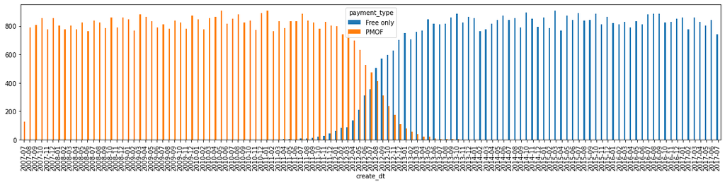

```python
data.create_dt = pd.to_datetime(data.create_dt)
tmp = data.groupby([data.create_dt.dt.to_period('M'), 'payment_type']).size().reset_index(name='acct_cnt').pivot_table(index='create_dt', columns='payment_type')['acct_cnt']
tmp.plot(kind='bar', figsize=(20,4))
```

Warning: The distributions of acct cnt for 'Free only' and 'PMOF' are significantly different. **They were sampled by different start time range**, and they only have limited overlap. More importantly, **it seems that total accts cnt start every month are uniformly distributed, while I believe this is not the case in reality as App Store has been growing fast. This makes growth analysis by start month cohort at acct level difficult.**

```python
del tmp
```

### Clean the Data and Update the Database

#### Normalize the Date Format to YYYY-MM-DD, and Exclude the Time Info

```python
data.to_csv(path+'account_dat_v1.csv', index=False, date_format='%Y-%m-%d')
```

#### Update the Table account_dat

```
sqlite
delete from account_dat;
.import --skip 1 'C:/Users/lingj/Documents/Personal/Career/Interview/Apple/App Store Data Scientist/account_dat_v1.csv' account_dat
```

```python
pd.read_sql('select * from account_dat limit 3;', con)
```

|  | acct_id | create_dt | payment_type |
| --- | --- | --- | --- |
| 0 | eb23e449d274bddb | 2012-04-03 | PMOF |
| 1 | 3d60dcb8494a0d70 | 2009-08-31 | PMOF |
| 2 | 9b6d6fbf76504d85 | 2008-11-06 | PMOF |

## app_dat.csv

```python
data = pd.read_csv(path+'app_dat.csv')
# data.profile_report(title='app_dat.csv')
```

This dataset can not be processed directly by profile_report function, so I will manually do the exploration. The same thereafter if there is any.

```python
data.head()
```

|  | app_name | content_id | category_id | device_id |
| --- | --- | --- | --- | --- |
| 0 | half-slouched having | 22dfac9721b899cb | Y-8 | 3 |
| 1 | lift whale-ships | 7c645810cd7f166e | M-7 | 3 |
| 2 | mightily community | c495bcb878faffaa | Y-8 | 2 |
| 3 | session: too--shall | 4e683dcd461cdd22 | Y-8 | 1 |
| 4 | That Zoology | 6473dd29a2badbf1 | Y-8 | 3 |

```python
data.info()
```

```
<class 'pandas.core.frame.DataFrame'>
RangeIndex: 1000 entries, 0 to 999
Data columns (total 4 columns):
 #   Column       Non-Null Count  Dtype
---  ------       --------------  -----
 0   app_name     1000 non-null   object
 1   content_id   1000 non-null   object
 2   category_id  1000 non-null   object
 3   device_id    1000 non-null   int64
dtypes: int64(1), object(3)
memory usage: 31.4+ KB
```

### Categorical

```python
# Distinct (%)
print(
    'app_name:\t{:.4%}\ncontent_id:\t{:.4%}\ncategory_id:\t{:.4%}\ndevice_id:\t{:.4%}'.format(
        data.app_name.unique().shape[0] / data.shape[0],
        data.content_id.unique().shape[0] / data.shape[0],
        data.category_id.unique().shape[0] / data.shape[0],
        data.device_id.unique().shape[0] / data.shape[0]
    )
)
```

```
app_name:	99.7000%
content_id:	100.0000%
category_id:	0.5000%
device_id:	0.3000%
```

There are some rows having duplicated app_name. Need to confirm if I need to do the dedup.

```python
# Frequency
print(data.app_name.groupby(data.app_name).size().sort_values(ascending=False).iloc[:3])
print(data.content_id.groupby(data.content_id).size().sort_values(ascending=False).iloc[:3])
print(data.category_id.groupby(data.category_id).size().sort_values(ascending=False).iloc[:3])
print(data.device_id.groupby(data.device_id).size().sort_values(ascending=False).iloc[:3])
```

```
app_name
#NAME?           4
noting Dry       1
moose society    1
Name: app_name, dtype: int64
content_id
002f3775d84a816a    1
a9bb29d9f416db71    1
a683e96f06a25bb3    1
Name: content_id, dtype: int64
category_id
Z-1    392
Y-8    260
M-7    153
Name: category_id, dtype: int64
device_id
3    815
2     97
1     88
Name: device_id, dtype: int64
```

4 rows of app_name are '#NAME?'. This could be from character encoding or other import error. No need to drop them now, but need to **be cautious when aggregating on the app_name in the later analysis**. Good news is that the corresponding content_id (app_id) is unique. A better solution is to rename '#NAME?' with numbering suffix so that they will not mess up with each other during aggregation.

Most of apps are available on both iPhone and iPad.

### Clean the Data and Update the Database

#### Add Suffix for App's Name of '#NAME?'

```python
tmp = data.app_name[data.app_name.duplicated(keep=False)]
tmp2 = data.app_name.values
```

```python
for i in range(len(tmp)):
    tmp2[tmp.index[i]] = '#NAME?' + str(i)
data.app_name = tmp2
```

```python
del tmp, tmp2
```

```python
data.to_csv(path+'app_dat_v1.csv', index=False)
```

#### Update the Table app_dat

```
sqlite
delete from app_dat;
.import --skip 1 'C:/Users/lingj/Documents/Personal/Career/Interview/Apple/App Store Data Scientist/app_dat_v1.csv' app_dat
```

```python
pd.read_sql("select * from app_dat where app_name like '#NAME?%';", con)
```

|  | app_name | content_id | category_id | device_id |
| --- | --- | --- | --- | --- |
| 0 | #NAME?0 | 9c2e16e0724fe92b | Z-1 | 3 |
| 1 | #NAME?1 | 8ead7768bac17788 | M-7 | 2 |
| 2 | #NAME?2 | 1ac2aa9abb7ff134 | Z-1 | 3 |
| 3 | #NAME?3 | d44e56b18c1f7a96 | M-7 | 3 |

## in-app_dat.csv

```python
data = pd.read_csv(path+'in-app_dat.csv')
data.profile_report(title='in-app_dat.csv')
```

[interactive chart not shown]

An app can have multiple IAP contents. 476 apps have IAP, which is fewer than total app number in app_dat.csv. Need to check whether 476 apps is the subset of 1000 apps in app_dat.csv.

```python
tmp = pd.read_csv(path+'app_dat.csv')
len(set(tmp.content_id).intersection(set(data.parent_app_content_id)))
```

```
476
```

All the parent apps are included in the app_dat.csv.

```python
del tmp
```

## device_ref.csv

```python
data = pd.read_csv(path+'device_ref.csv')
# data.profile_report(title='device_ref.csv')
```

```python
data.head()
```

|  | device_name | device_id |
| --- | --- | --- |
| 0 | iPhone | 1 |
| 1 | iPad | 2 |
| 2 | Both | 3 |

Simply a mapping table for device_name and device_id

## category_ref.csv

```python
data = pd.read_csv(path+'category_ref.csv')
data.profile_report(title='category_ref.csv')
```

[interactive chart not shown]

Simply a mapping table for category_name and category_id.

## transaction_dat.csv

```python
data = pd.read_csv(path+'transaction_dat.csv')
# data.profile_report(title='transaction_dat.csv')
```

```python
data.head()
```

|  | create_dt | content_id | acct_id | price | device_id |
| --- | --- | --- | --- | --- | --- |
| 0 | 2016-08-28 | b6cf4f33e7455df4 | 220574a7a6a71afa | 11.99 | 1 |
| 1 | 2016-09-16 | 71ac3e9c38ddbbba | 8551f69a5015ea6a | 1.99 | 2 |
| 2 | 2016-08-15 | 776b851b916c33d1 | 7dedf309494a1966 | 0.99 | 2 |
| 3 | 2016-06-17 | 7a47ca132a8dc695 | 7174a81c796dcf7e | 1.99 | 2 |
| 4 | 2016-06-13 | 30581219bc952dbb | 35aaf59d64a677e7 | 11.99 | 2 |

```python
data.info()
```

```
<class 'pandas.core.frame.DataFrame'>
RangeIndex: 3607509 entries, 0 to 3607508
Data columns (total 5 columns):
 #   Column      Dtype
---  ------      -----
 0   create_dt   object
 1   content_id  object
 2   acct_id     object
 3   price       float64
 4   device_id   int64
dtypes: float64(1), int64(1), object(3)
memory usage: 137.6+ MB
```

### Categorical

```python
# Distinct (%)
print(
    'create_dt:\t{:.4%}\ncontent_id:\t{:.4%}\nacct_id:\t{:.4%}\ndevice_id:\t{:.4%}'.format(
        data.create_dt.unique().shape[0] / data.shape[0],
        data.content_id.unique().shape[0] / data.shape[0],
        data.acct_id.unique().shape[0] / data.shape[0],
        data.device_id.unique().shape[0] / data.shape[0]
    )
)
```

```
create_dt:	0.0030%
content_id:	0.0807%
acct_id:	0.8316%
device_id:	0.0001%
```

```python
# Frequency
print(data.create_dt.groupby(data.create_dt).size().sort_values(ascending=False).iloc[:3])
print(data.content_id.groupby(data.content_id).size().sort_values(ascending=False).iloc[:3])
print(data.acct_id.groupby(data.acct_id).size().sort_values(ascending=False).iloc[:3])
print(data.device_id.groupby(data.device_id).size().sort_values(ascending=False).iloc[:3])
```

```
create_dt
2016-07-04    36911
2016-09-04    35384
2016-09-17    35155
Name: create_dt, dtype: int64
content_id
d9ac236641bd3859    11943
d97771dfca471b80    11927
c31b6ffb3bc47d7f    11349
Name: content_id, dtype: int64
acct_id
025488c9dcfdee47    1356
e2ea593fd4f17918    1352
8574c2b7af1573ac    1348
Name: acct_id, dtype: int64
device_id
1    2614356
2     993153
Name: device_id, dtype: int64
```

```python
tmp = pd.to_datetime(data.create_dt)
print(
    'min create_dt:\t{}\nmax create_dt:\t{}'.format(
        tmp.min(),
        tmp.max()
    )
)
```

```
min create_dt:	2016-06-01 00:00:00
max create_dt:	2016-09-21 00:00:00
```

Warning: **the range of transaction date is much smaller than the range of account create date!** Be cautious when joining acct table and txn table.

```python
del tmp
```

#### Check content_id Linkage Rate to Table in_app_dat and app_dat

```python
query = '''
select
    round(count(*)/3607509.0, 2) linkage_pct_to_content_id
from
    transaction_dat a
    join in_app_dat b on a.content_id=b.content_id
;
'''
pd.read_sql(query, con)
```

|  | linkage_pct_to_content_id |
| --- | --- |
| 0 | 0.56 |

Only 56% of transaction record can be linked to content_id in the table in_app_dat.

```python
query = '''
select
    round(count(*)/3607509.0, 2) linkage_pct_to_app_id
from
    transaction_dat a
    join app_dat b on a.content_id=b.content_id
;
'''
pd.read_sql(query, con)
```

|  | linkage_pct_to_app_id |
| --- | --- |
| 0 | 0.44 |

Luckily, the remaining 44% are found linkage directly to the content_id (app_id) in the table app_dat. I guess for these apps, only one purchase item is available in these apps, so they do not appear in the table in_app_dat.

#### Check acct_id Linkage Rate to Table account_dat

```python
query = '''
select
    b.payment_type acct_payment_type,
    case
        when a.price>0 then 'paid txn'
        else 'free txn'
    end txn_payment_type,
    round(count(distinct b.acct_id)/100000.0, 2) linkage_pct_to_acct_id
from
    transaction_dat a
    join account_dat b on a.acct_id=b.acct_id
group by
    b.payment_type,
    case
        when a.price>0 then 'paid txn'
        else 'free txn'
    end
;
'''
pd.read_sql(query, con)
```

|  | acct_payment_type | txn_payment_type | linkage_pct_to_acct_id |
| --- | --- | --- | --- |
| 0 | Free only | free txn | 0.15 |
| 1 | PMOF | free txn | 0.15 |
| 2 | PMOF | paid txn | 0.15 |

Only part of accounts have transaction records in the table transaction_dat. It seems that transactions with no cash payment are also included in the table, and they have no-paid transactions only. I can check the distribution of price in the next step.

### Numerical

```python
data.price.describe()
```

```
count    3.607509e+06
mean     5.280511e+00
std      6.960452e+00
min      0.000000e+00
25%      0.000000e+00
50%      1.990000e+00
75%      7.990000e+00
max      2.999000e+01
Name: price, dtype: float64
```

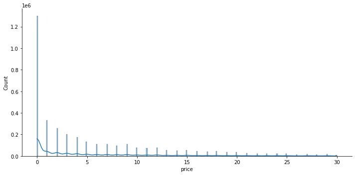

```python
sns.displot(data.price, kde=True, aspect=2)
```

Though price is a numeric field, the distribution is rugged and the range is not continuous. It seems that most of the prices are ended with .99 probably coming from regression discontinuity on customer purchase behavior analysis. We can see it more clearly below.

```python
data.price.groupby(data.price).size().sort_values(ascending=False).iloc[:10]
```

```
price
0.00    1302194
0.99     332492
1.99     255790
2.99     204189
3.99     173033
4.99     131962
5.99     110628
6.99     110397
8.99     107845
7.99      97863
Name: price, dtype: int64
```